# Project: Investigate a Dataset (No show appointments)

- Introduction
- Data Wrangling
- Exploratory Data Analysis
- Conclusions

## Introduction

> We will be exploring the **No_show database** to try and figure out how the different variables contribute to no shows.

Some of the questions we will be asking include;

1. What gender honours their appointments more?
2. How do different age groups contribute to shows and no shows?
3. Do people who received an SMS have more shows than those who did not receive an SMS.
4. What features seem to be contributing more to no shows?
5. Does the hospitals location plays any role in the number of now shows?

```python
#Import important packages that we will use to investigate the dataset
import pandas as pd
import numpy as np
import matplotlib.pyplot as plt
import seaborn as sns

%matplotlib inline
```

## Data Wrangling

### General Properties

```python
# read the data and check out the first few rows
app_df = pd.read_csv('noshow_data.csv')

app_df.head()
```

|  | PatientId | AppointmentID | Gender | ScheduledDay | AppointmentDay | Age | Neighbourhood | Scholarship | Hipertension | Diabetes | Alcoholism | Handcap | SMS_received | No-show |
| --- | --- | --- | --- | --- | --- | --- | --- | --- | --- | --- | --- | --- | --- | --- |
| 0 | 2.987250e+13 | 5642903 | F | 2016-04-29T18:38:08Z | 2016-04-29T00:00:00Z | 62 | JARDIM DA PENHA | 0 | 1 | 0 | 0 | 0 | 0 | No |
| 1 | 5.589978e+14 | 5642503 | M | 2016-04-29T16:08:27Z | 2016-04-29T00:00:00Z | 56 | JARDIM DA PENHA | 0 | 0 | 0 | 0 | 0 | 0 | No |
| 2 | 4.262962e+12 | 5642549 | F | 2016-04-29T16:19:04Z | 2016-04-29T00:00:00Z | 62 | MATA DA PRAIA | 0 | 0 | 0 | 0 | 0 | 0 | No |
| 3 | 8.679512e+11 | 5642828 | F | 2016-04-29T17:29:31Z | 2016-04-29T00:00:00Z | 8 | PONTAL DE CAMBURI | 0 | 0 | 0 | 0 | 0 | 0 | No |
| 4 | 8.841186e+12 | 5642494 | F | 2016-04-29T16:07:23Z | 2016-04-29T00:00:00Z | 56 | JARDIM DA PENHA | 0 | 1 | 1 | 0 | 0 | 0 | No |

We can see from the table above that some of the column names are too long, mispelt or contain inappropriate separators. Though not necessary for analysis, we will rename them to make them more consistent with the norms and easier to use

```python
#Let us check out some summary statistics to ensure that the values make sense.
app_df.describe()
```

|  | PatientId | AppointmentID | Age | Scholarship | Hipertension | Diabetes | Alcoholism | Handcap | SMS_received |
| --- | --- | --- | --- | --- | --- | --- | --- | --- | --- |
| count | 1.105270e+05 | 1.105270e+05 | 110527.000000 | 110527.000000 | 110527.000000 | 110527.000000 | 110527.000000 | 110527.000000 | 110527.000000 |
| mean | 1.474963e+14 | 5.675305e+06 | 37.088874 | 0.098266 | 0.197246 | 0.071865 | 0.030400 | 0.022248 | 0.321026 |
| std | 2.560949e+14 | 7.129575e+04 | 23.110205 | 0.297675 | 0.397921 | 0.258265 | 0.171686 | 0.161543 | 0.466873 |
| min | 3.921784e+04 | 5.030230e+06 | -1.000000 | 0.000000 | 0.000000 | 0.000000 | 0.000000 | 0.000000 | 0.000000 |
| 25% | 4.172614e+12 | 5.640286e+06 | 18.000000 | 0.000000 | 0.000000 | 0.000000 | 0.000000 | 0.000000 | 0.000000 |
| 50% | 3.173184e+13 | 5.680573e+06 | 37.000000 | 0.000000 | 0.000000 | 0.000000 | 0.000000 | 0.000000 | 0.000000 |
| 75% | 9.439172e+13 | 5.725524e+06 | 55.000000 | 0.000000 | 0.000000 | 0.000000 | 0.000000 | 0.000000 | 1.000000 |
| max | 9.999816e+14 | 5.790484e+06 | 115.000000 | 1.000000 | 1.000000 | 1.000000 | 1.000000 | 4.000000 | 1.000000 |

From the above summary statistics, we can see that there is something wrong with the age column. Some of the values are definitely wrong as we cannot have someone with a negative age.

Let us investigate further to see how the age column is.

```python
#We can start by checking out the count of ages with low values
app_df['Age'].value_counts().sort_index(ascending=False).tail(20)
```

```
 18    1487
 17    1509
 16    1402
 15    1211
 14    1118
 13    1103
 12    1092
 11    1195
 10    1274
 9     1372
 8     1424
 7     1427
 6     1521
 5     1489
 4     1299
 3     1513
 2     1618
 1     2273
 0     3539
-1        1
Name: Age, dtype: int64
```

We can see that there is one variable with a negative value. This was probably a typo and we can change the -1 to 1 or drop it without affecting the data much. The other low ages are 0 and 1. They however have more values meaning that some of the observations are for young children below 1 year.

```python
# next we will check for missing values for each variable
print("No of null values\n\n", app_df.isnull().sum())

app_df.nunique()
```

```
No of null values

 PatientId         0
AppointmentID     0
Gender            0
ScheduledDay      0
AppointmentDay    0
Age               0
Neighbourhood     0
Scholarship       0
Hipertension      0
Diabetes          0
Alcoholism        0
Handcap           0
SMS_received      0
No-show           0
dtype: int64
```

```
PatientId          62299
AppointmentID     110527
Gender                 2
ScheduledDay      103549
AppointmentDay        27
Age                  104
Neighbourhood         81
Scholarship            2
Hipertension           2
Diabetes               2
Alcoholism             2
Handcap                5
SMS_received           2
No-show                2
dtype: int64
```

The data set seems to be missing no values. Let us check the data types of the different variables to make sure they are typed correctly.

```python
#Let is get the info of the various columns
print(app_df.info())

#Let us also check for duplicates
app_df.duplicated().sum()
```

```
<class 'pandas.core.frame.DataFrame'>
RangeIndex: 110527 entries, 0 to 110526
Data columns (total 14 columns):
 #   Column          Non-Null Count   Dtype
---  ------          --------------   -----
 0   PatientId       110527 non-null  float64
 1   AppointmentID   110527 non-null  int64
 2   Gender          110527 non-null  object
 3   ScheduledDay    110527 non-null  object
 4   AppointmentDay  110527 non-null  object
 5   Age             110527 non-null  int64
 6   Neighbourhood   110527 non-null  object
 7   Scholarship     110527 non-null  int64
 8   Hipertension    110527 non-null  int64
 9   Diabetes        110527 non-null  int64
 10  Alcoholism      110527 non-null  int64
 11  Handcap         110527 non-null  int64
 12  SMS_received    110527 non-null  int64
 13  No-show         110527 non-null  object
dtypes: float64(1), int64(8), object(5)
memory usage: 11.8+ MB
None
```

```
0
```

The data objects are mostly typed correctly but we need to change the data type of the scheduled day and appointment day incase we want to run calculations on them.

### Data Cleaning

```python
# Option 1 - Change the - value to + remember to run only once because the formula works with the min values.
#app_df.at[app_df['Age'].idxmin(), 'Age'] = 1

#Option 2 - Drop the row that contains the -1 row by subsetting those that have other values.
app_df = app_df[app_df['Age'] != -1]
app_df['Age'].value_counts().sort_index(ascending=False).tail(20)
```

```
19    1545
18    1487
17    1509
16    1402
15    1211
14    1118
13    1103
12    1092
11    1195
10    1274
9     1372
8     1424
7     1427
6     1521
5     1489
4     1299
3     1513
2     1618
1     2273
0     3539
Name: Age, dtype: int64
```

```python
#Let us convert the columns to lower case and replace hyphens with underscores
#app_df.columns = app_df.columns.str.lower().str.replace('-',"_") - one way to do this.
app_df.rename(lambda x: x.lower().replace("-","_"), axis=1, inplace=True)

#rename the appointmentday, schedule day and hipertension columns
app_df.rename(columns={'appointmentday':'app_day', 'scheduledday':'sch_day', 'hipertension':'hypertension','patientid':'pat_id','appointmentid':'app_id', 'handcap':'handicap'}, inplace=True)

#Create a function to change types, default type is datetime
def to_type(cols,df, t='M'):
    for c in cols:
        df[c] = df[c].astype(t)
        return df
#change types of the sch_day and app_day
columns =['sch_day', 'app_day']

app_df = to_type(columns,app_df)

#check to see if the cleaning is complete
print(app_df.columns)
app_df.info()
```

```
Index(['pat_id', 'app_id', 'gender', 'sch_day', 'app_day', 'age',
       'neighbourhood', 'scholarship', 'hypertension', 'diabetes',
       'alcoholism', 'handicap', 'sms_received', 'no_show'],
      dtype='object')
<class 'pandas.core.frame.DataFrame'>
Int64Index: 110526 entries, 0 to 110526
Data columns (total 14 columns):
 #   Column         Non-Null Count   Dtype
---  ------         --------------   -----
 0   pat_id         110526 non-null  float64
 1   app_id         110526 non-null  int64
 2   gender         110526 non-null  object
 3   sch_day        110526 non-null  datetime64[ns]
 4   app_day        110526 non-null  object
 5   age            110526 non-null  int64
 6   neighbourhood  110526 non-null  object
 7   scholarship    110526 non-null  int64
 8   hypertension   110526 non-null  int64
 9   diabetes       110526 non-null  int64
 10  alcoholism     110526 non-null  int64
 11  handicap       110526 non-null  int64
 12  sms_received   110526 non-null  int64
 13  no_show        110526 non-null  object
dtypes: datetime64[ns](1), float64(1), int64(8), object(4)
memory usage: 12.6+ MB
```

## Exploratory Data Analysis

Now that we have cleaned our data, we will go ahead and explore it to come up with findings that may allow us to understand the data better. We are also going to answer some of the questions that we posited earlier.

### 1. Which gender honours their appointments more?

```
gender  no_show
F       No         57245
        Yes        14594
M       No         30962
        Yes         7725
Name: no_show, dtype: int64
```

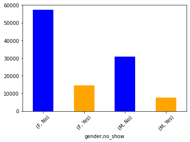

```python
#Get no shows and shows df
app_df.groupby('gender')['no_show'].value_counts().plot(kind = 'bar', rot = 45, color = ['blue', 'orange'])
app_df.groupby('gender')['no_show'].value_counts()
```

We can see that more women show up for their appointments. But it is also more clear that more women make appointments so we need to investigate proportions of men and women who show up against those who made appointments.

```
total men : 38687, Total women : 71839
Proportion of men no shows to total male appointments : 19.97%
Proportion of women no shows to total female appointments : 20.31%
```

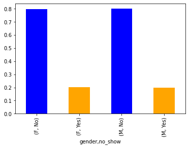

```python
#Total appointments for the different groups

total_m = app_df.query('gender == "M"').shape[0]
total_f = app_df.query('gender == "F"').shape[0]

#Men nos shows and proportion to total men appoitments
m_ns = app_df.query('gender == "M" and no_show == "Yes"')
m_ns_p = m_ns.shape[0]/total_m

#Women nos shows and proportion to total men appoitments
f_ns = app_df.query('gender == "F" and no_show == "Yes"')
f_ns_p = f_ns.shape[0]/total_f

print(f"total men : {total_m}, Total women : {total_f}")
print(f"Proportion of men no shows to total male appointments : {round(m_ns_p*100,2)}%")
print(f"Proportion of women no shows to total female appointments : {round(f_ns_p*100,2)}%")

app_df.groupby('gender')['no_show'].value_counts(normalize = True).plot(kind='bar', color=['blue', 'orange']);
```

We can see from the above that the proportion of no shows for both men and women to each categories total appointments is approximately 20%. This means that in as much as more women show up, it may be because more of them make appointment.

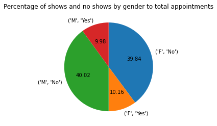

```python
pp = app_df.groupby(['gender'])['no_show'].value_counts(normalize=True)
plt.pie(pp, labels=pp.index,autopct="%.2f", startangle=90, counterclock=False)
plt.title("Percentage of shows and no shows by gender to total appointments");
```

### 2. How do different age groups contribute to shows and no shows?

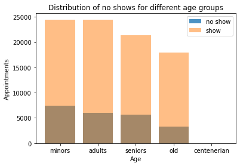

```python
#create age groups
age_bins= [0,18,40,60,100,130]
labels=['minors', 'adults', 'seniors','old','centenerian']
app_df['age_group']= pd.cut(app_df['age'], bins=age_bins, labels=labels, right=False)

#check for the distribution of no shows for different age groups
ns_df = app_df.query('no_show == "Yes"')
s_df = app_df.query('no_show == "No"')
age_group_ns = ns_df.age_group.value_counts()
age_group_s = s_df.age_group.value_counts()

#plot the distribution of no shows and shows for each age group

plt.bar(x = labels, height=age_group_ns, alpha=0.8, label='no show')
plt.bar(x = labels,height=age_group_s, alpha=0.5, label='show')
plt.xlabel('Age')
plt.ylabel('Appointments')
plt.title('Distribution of no shows for different age groups')
plt.legend();
```

The young and middle age population seems to have a higher proportion of no shows compared to the older populations. Let us investigate the *young* and *middle* ages populations further.

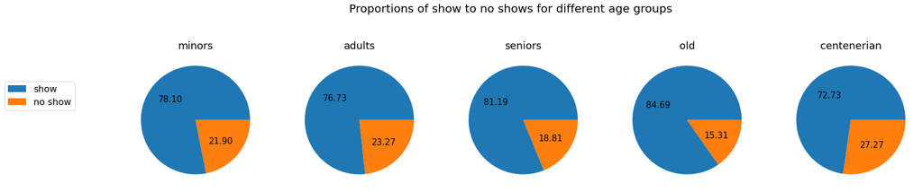

```python
ns_proportions = app_df.groupby('age_group')['no_show'].value_counts(normalize=True)

categories = ['minors', 'adults', 'seniors','old','centenerian']

fig, ax = plt.subplots(1,5, figsize=(25,6))

for index, cat in enumerate(categories):
    #print(index, ns_proportions[cat])
    ax[index].pie(ns_proportions[cat], labels=['show', 'no show'],labeldistance = None, autopct='%.2f', textprops={'fontsize': 15})
    ax[index].set_title(cat, fontsize=18)

fig.legend(['show', 'no show'], loc=6, fontsize=16)
fig.suptitle('Proportions of show to no shows for different age groups', fontsize=20);
```

From the above we can see that the more *minors, seniors* and *old* peopled show up for their appointments as compared to adults and centenerians.

### 3. Do people who receive an SMS have more shows than those who did not receive an SMS.

```python
#Get proportions of shows and no shows based on whether a message was received or not.
sms_p = app_df.groupby('sms_received')['no_show'].value_counts(normalize=True)
sms_p
```

```
sms_received  no_show
0             No         0.832965
              Yes        0.167035
1             No         0.724255
              Yes        0.275745
Name: no_show, dtype: float64
```

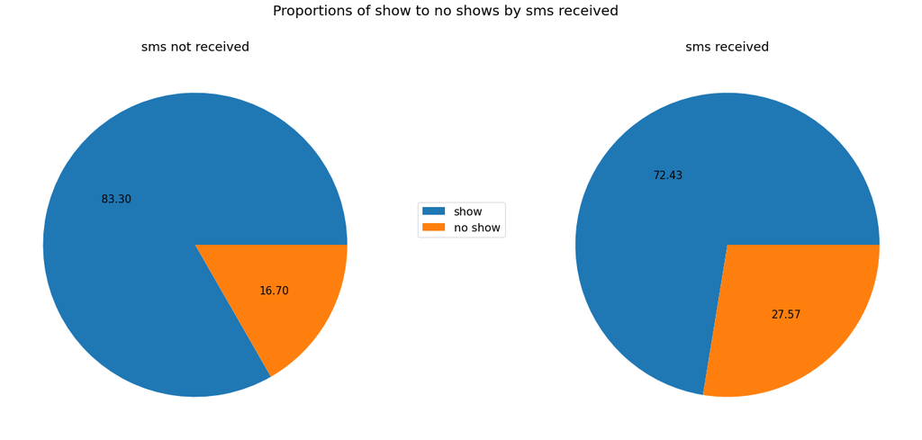

```python
#plot chart for proportions of show and no show by sms received
sms_cat = [0,1]

fig, ax = plt.subplots(1,2, figsize=(25,10))

for cat in sms_cat:
    ax[cat].pie(sms_p[cat],labeldistance = None, autopct='%.2f', textprops={'fontsize': 15})
    ax[cat].set_title((lambda x: (x == 1 and 'sms received' or 'sms not received'))(cat), fontsize=18)

#plt.title("Proportions of no shows to shows for each age group",pad=60,loc='left')
fig.legend(['show', 'no show'], loc=10, fontsize=16)
fig.suptitle('Proportions of show to no shows by sms received', fontsize=20);
```

Sending an sms does not guarantee that more people will show up as the two charts shows that a bigger proportion of people who did not receive an sms showed up for their appointments none the less.

### 4. What features seem to be contributing more to shows?

Here, we are going to check the shows and no shows numbers and proportions for the *scholarship, hypertension, diabetes, alcoholism* and *handicap* features.

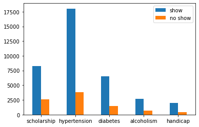

```python
coi = [x for x in app_df.columns[7:12]]
app_df.groupby(['no_show'])[coi].sum().T.plot(kind = 'bar', rot=0);
plt.legend(['show', 'no show'])
```

### 5. Does the hospitals location plays any role in the number of now shows?

```python
#Subset df for no shows, groupby neighbourhood and count the no_show values. Sort the values and plot values
app_df.query('no_show == "Yes"').groupby('neighbourhood')['no_show'].count().sort_values(ascending=False).plot(kind='bar', figsize=(130,50), fontsize=75)
plt.title('Count of no shows for different hospitals', fontsize=150);
```

[figure not shown]

```python
app_df.query('no_show == "Yes"').groupby('neighbourhood')['no_show'].count().describe()
```

```
count      80.000000
mean      278.987500
std       278.000751
min         1.000000
25%        75.000000
50%       184.500000
75%       428.250000
max      1465.000000
Name: no_show, dtype: float64
```

From the distribution of no shows for the various hospitals, we can see that half of the neighbourhoods contribute most to most no shows

## Conclusions

Further analysis of the data needs to be done to esstablish deeper relationships within the variables. We have not yet established what variables are more likely to contribute to less no shows and further statistical methods have to be applied to establish this.

#### References

Some of the references I used to come up with the analysis include:

- [W3 Schools Python Lambda](https://www.w3schools.com/python/python_lambda.asp)
- [StackOverflow Multiple Pie charts](https://stackoverflow.com/questions/57314529/multiple-pie-charts-from-pandas-dataframe)
- [Geeks for Geeks Matplotlib axes](https://www.geeksforgeeks.org/matplotlib-axes-axes-pie-in-python/)
- [Geeks for Geeks drop rows based on sepcific column values](https://www.geeksforgeeks.org/how-to-drop-rows-that-contain-a-specific-value-in-pandas/)
- [Real python lambda functions](https://realpython.com/python-lambda/)
- [Official matplotlib](https://matplotlib.org/stable/api/index.html)
- [Official pandas](https://pandas.pydata.org/pandas-docs/stable/reference/index.html)

Plus most of the class notes.